# Seasonal comparisons

MW Beck

06 October, 2021

## WRTDStidal approach

These plots show model predicted chlorophyll as a function of time, season, and salinity using a WRTDS approach described [here](http://fawda123.github.io/WRTDStidal/articles/overview.html). The results provide an estimate of chlorophyll trends at different conditional percentiles of the response, in this case, the median and 90th percentile (tau = 0.5, 0.9). A “flow-normalized” trend independent of salinity is also provided. The top plot shows predicted chlorophyll (lines) for the different percentiles overlaid on the observed values (points). The middle plot shows flow-normalized chlorophyll (lines) against the predictions (points). Importantly, predictions for 2021 show little difference between the flow-normalized and predicted results, suggesting little influence of freshwater inputs into the system. The bottom two plots show the flow-normalized results by day of year, with separate lines by year. Note the uptick in 2021 flow-normalized predictions (thicker line) of chlorophyll for some stations.

### Station 21

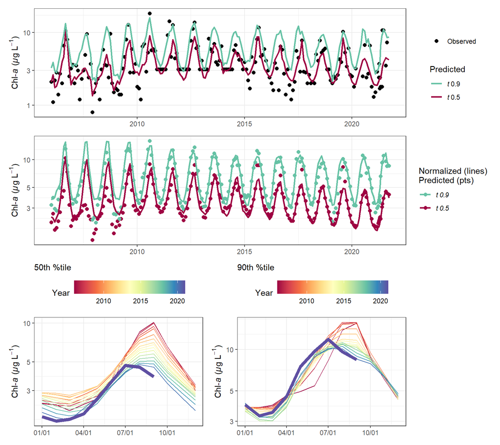

### Station 22

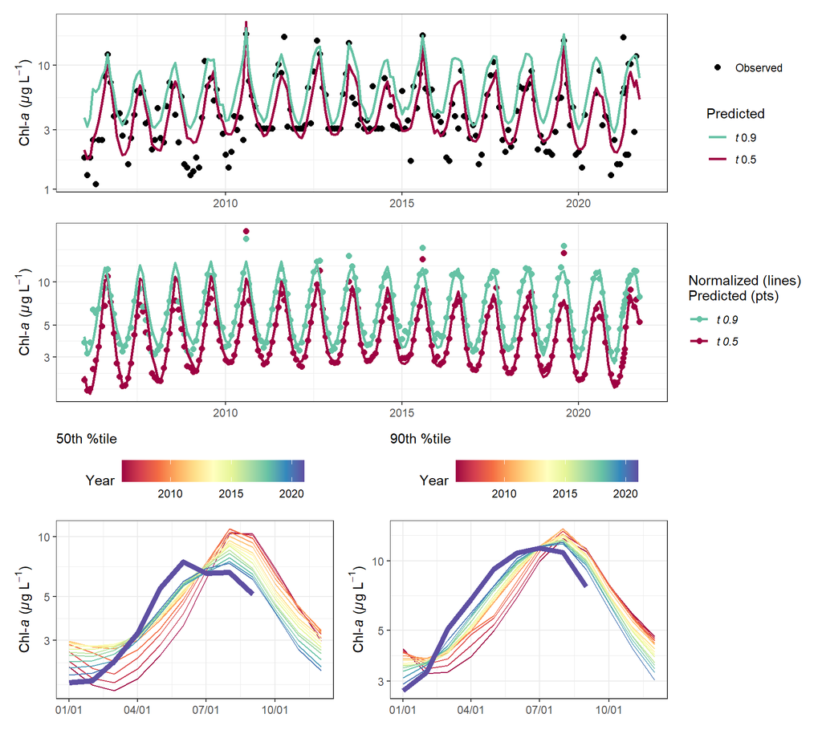

### Station 90

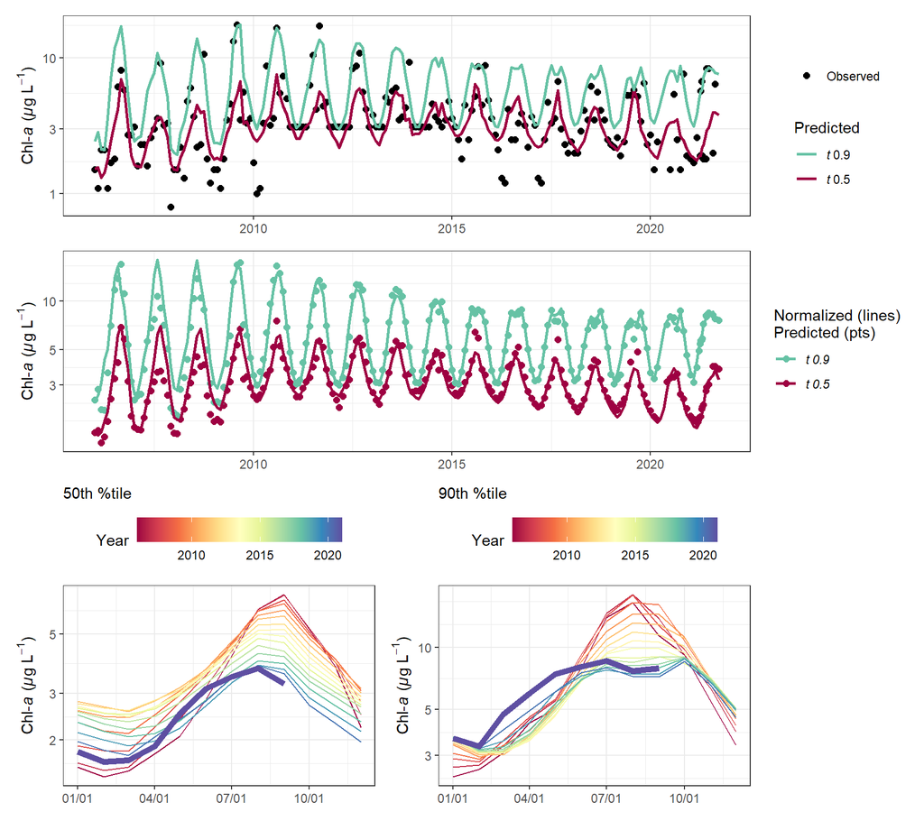

## wqtrends approach

These plots show model-predicted chlorophyll (as a function of time) using a GAMs approach described [here](https://tbep-tech.github.io/wqtrends/articles/introduction.html). The basic idea is to model a signal of a long-term seasonal and annual trend from an observed time series and then extract a seasonal metric of interest from the modelled signal. The seasonal metric applies to an a priori window of time (e.g., March, April, etc.) and includes statistical uncertainty that can be used for additional hypothesis testing. The results do not include any flow-adjusted or hydrologic inputs.

### Station 21

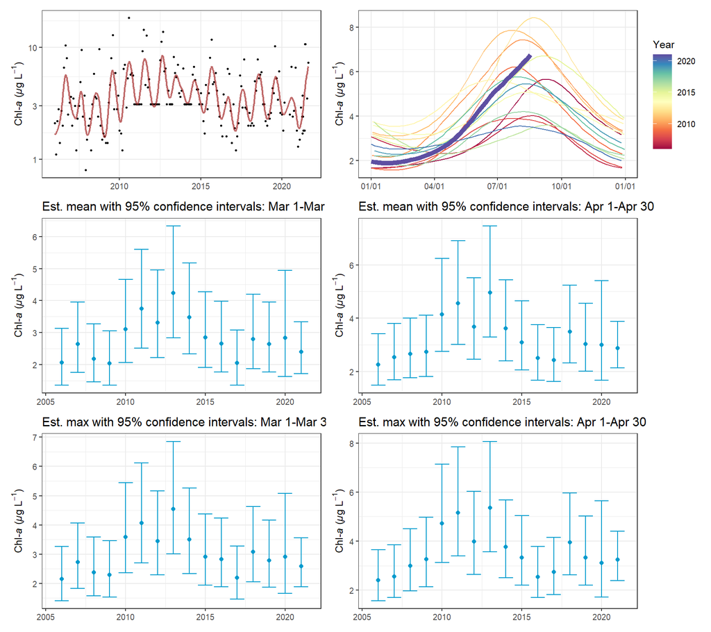

### Station 22

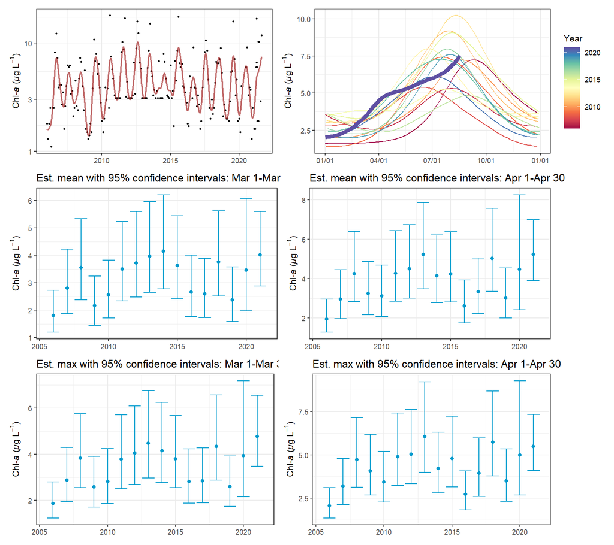

### Station 90

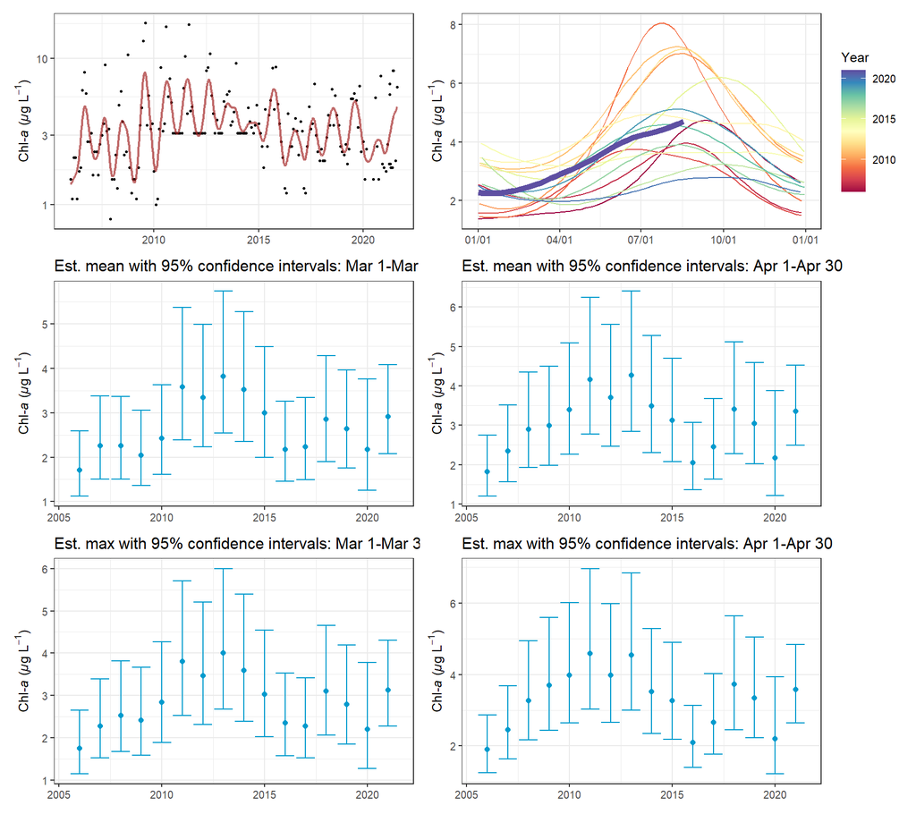

## Observed and aggregated data

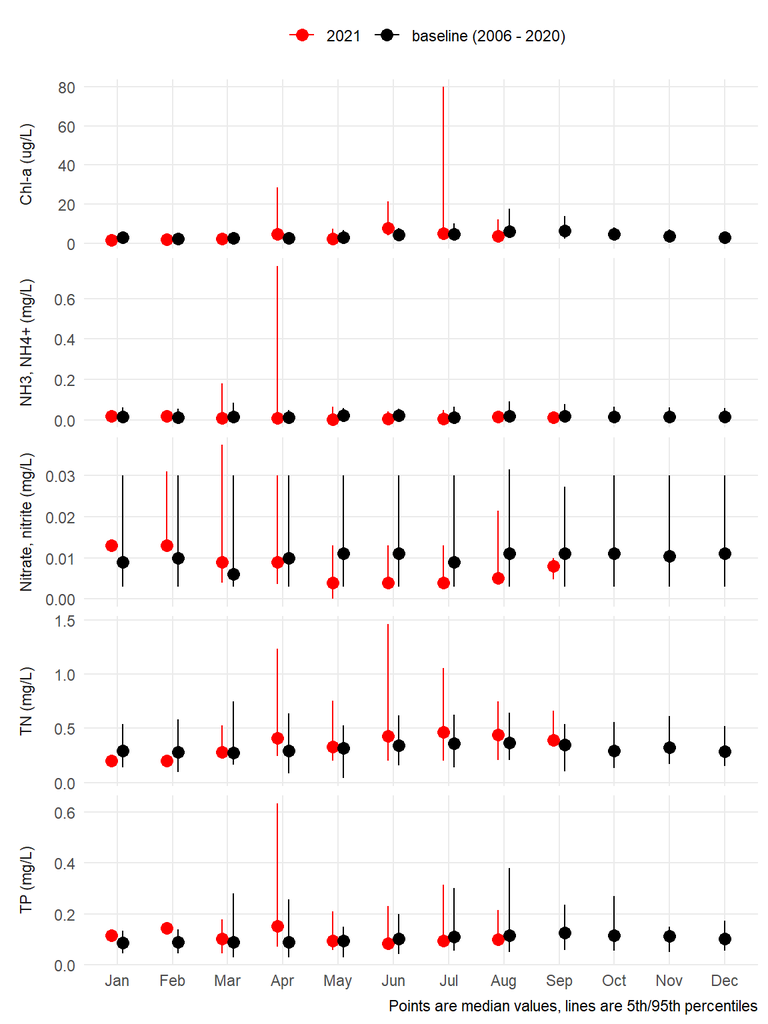